# Determinants of writing positive and negative electronic word-of-mouth_ Empirical evidence for two types of expectation confirmation

Converted from PDF `Nam-ElectronicWOMDeterminants-2020-DSS.pdf` · 14 pages · anchors: page `#pN`, block `#pN-bK`

Page 1

Contents lists available at ScienceDirect

## Decision Support Systems

journal homepage: www.elsevier.com/locate/dss

### Determinants of writing positive and negative electronic word-of-mouth: Empirical evidence for two types of expectation confirmation

### Kichan Nam<sup>a</sup>, Jeff Baker<sup>a</sup><sup>,</sup><sup>⁎</sup>, Norita Ahmad<sup>a</sup>, Jahyun Goo<sup>b</sup>

a *Department of Marketing and Information Systems, American University of Sharjah, Sharjah, United Arab Emirates* b *Information Technology and Operations Management, Florida Atlantic University, Boca Raton, FL 33431, USA*

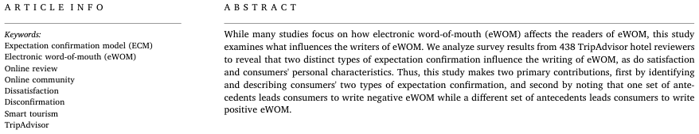

NOTE: complex table shown as an image of the PDF; the text below is a rough machine extraction and may be mis-aligned.

**extracted text (unreliable layout)**

#### **1. Introduction**

Researchers have long understood the importance of word-of-mouth (WOM) in shaping consumers' opinions and behaviors [1–6]. With the advent of the Internet, the study of WOM communication has also come to include the study of electronic word-of-mouth (eWOM). eWOM is “any positive or negative statement made by potential, actual, or former customers about a product or company, which is made available to a multitude of people and institutions via the Internet” ([7] p. 39). eWOM possesses several unique characteristics that distinguish it from WOM, including greater scalability, speed of diffusion, persistency, accessibility, measurability, and quantifiability [8–11]. With the growing use of social media platforms, eWOM is becoming a popular source of obtaining reliable information as well as influencing consumers [12]. For instance, the influence of eWOM is undeniable [13–16], with 91% of individuals consulting blogs, product reviews, or other online usergenerated comments before buying a product or service, 84% stating that they trust online reviews as much as a personal recommendation, and 74% of consumers stating that positive reviews make them trust a business more [17]. The specific influence of negative reviews has also been noted [11], with researchers observing that negative reviews are particularly influential for consumers [18], and thus have significant influence on firms' financial returns, customer churn, business continuity, and growth. Because practitioners are keenly focused on these outcomes, researchers are also continuing to study eWOM.

Given the unique characteristics of eWOM, its influence on consumers, its relevance for businesses, and the differing effects of positive and negative eWOM, several important questions arise. What determines whether people write eWOM or choose not to? Are the determinants for writing positive eWOM the same as from those for writing negative eWOM – and if they differ, how so? While researchers have studied online reviews and eWOM for many years, much of this foregoing work has examined how eWOM influences readers of eWOM. We take an alternate perspective, examining what influences writers of eWOM. Put differently, we intend in this paper to shift focus from factors on the consumption side of eWOM to those on the supply side of eWOM.

Furthermore, while a small number of studies examine reviewers' motivation for writing eWOM [19,20], to the best of our knowledge, this paper is the first to study reviewers' potentially differing motivations for writing positive or negative eWOM. The specific purpose of our study is thus to develop a model that explains determinants of writing positive eWOM and negative eWOM, and to find out how determinants of writing positive eWOM are different from those of writing negative eWOM.

Toward this purpose, we build a research model based on the expectation confirmation model (ECM) as we consider how expectation confirmation, satisfaction, and personal characteristics influence whether consumers choose to author eWOM that is positive or negative. One of the major contributions of this study is that we develop and

https://doi.org/10.1016/j.dss.2019.113168 Received 30 April 2019; Received in revised form 7 October 2019; Accepted 8 October 2019

⁎ Corresponding author.

*E-mail addresses:* knam@aus.edu (K. Nam), jbaker@aus.edu (J. Baker), nahmad@aus.edu (N. Ahmad), jgoo@fau.edu (J. Goo).

Decision Support Systems 129 (2020) 113168

Available online 22 October 2019 0167-9236/ © 2019 Elsevier B.V. All rights reserved.

Page 2

integrate two distinct types of expectation confirmation into our research model: the first type is the *offline expectation confirmation* that forms after individuals experience a degree of confirmation of their expectations about a real-world product or service (such as a hotel stay); and the second type is the *online expectation confirmation* that forms as individuals assess the accuracy of prior eWOM such as the online reviews that led them to purchase a product or service.

The paper proceeds as follows. We first review prior literature on WOM, then narrow our focus to studies of eWOM. We then describe the ECM, which is the theoretical foundation that undergirds a major contribution of this study, namely our explanation of reviewers' eWOM writing behavior. In the Method section, we explain our survey methodology, operationalization of constructs, instrument validation, and data collection from TripAdvisor reviewers (*n* = 438). We analyze our results using PLS and logistic regression, finding that there are different factors that influence consumers to write positive eWOM and negative eWOM. We also find evidence for two distinct types of expectation confirmation in eWOM writing behavior. Specifically, we find that individuals first experience confirmation of their expectations about a real-world, offline product or service such as a hotel stay, and then second, confirmation of their expectations about the accuracy of prior eWOM such as online reviews. Our results indicate that these two types of expectation confirmation differ in the way that they influence the likelihood that consumers write eWOM. Distinct sets of antecedents are identified for writers of positive eWOM and for writers of negative eWOM. We discuss the theoretical implications of these findings, and explore the practical implications both for websites that publish eWOM as well as for businesses that are affected by it. We note directions for future research before concluding.

#### **2. Prior research**

*2.1. WOM and eWOM*

Researchers have studied WOM for decades, consistently noting its importance in shaping individuals' opinions and behavior. Initial studies focused on how and why WOM was generated, identifying that greater levels of involvement – including involvement with the product/service being described, with other consumers, with messages about the product/service, and even involvement with and awareness of one's own needs as a consumer – lead to increased WOM [3]. Others noted the importance of integration into a community of consumers in receiving WOM and allowing it to shape behavior, and unsurprisingly observed that positive WOM regarding a product/service increases the likelihood of its purchase while negative WOM decreases the likelihood of its purchase [1]. From this early base of work, researchers have gone on to explain that WOM communication is an extremely important process through which individuals share opinions and information about goods and services [21]. WOM often has a greater influence on individuals' perceptions than traditional marketer-generated sources of information and even third-party “expert” reviews [2]. Individuals clearly seem willing to receive WOM messages and make decisions based on information from those whom they perceive to be unbiased peers [4,8].

Research on WOM has been extended to include electronic eWOM, which is defined as “any positive or negative statement made by potential, actual, or former customers about a product or company, which is made available to a multitude of people and institutions via the Internet” ([7] p. 39). Six major characteristics distinguish eWOM from WOM and contribute to its popularity and increasing use [4]: (1) the opinions and information shared can immediately reach a wide audience (2) eWOM recipients can seek information from multiple review sites, (3) eWOM is immediately available and has a persistent (perhaps permanent) digital footprint, (4) the anonymous nature of eWOM, where writers often cannot be identified or held accountable for their comments encourages people to publish it, (5) individuals can build up

social networks and status within those networks by writing eWOM, and (6) consumers increasingly rely on other consumers' eWOM-based opinions because eWOM generally has a clear negative or positive valence. Product/service information from friends, relatives, or an online community is viewed as more honest, credible, and trustworthy than that provided through merchants' websites and advertisements.

Empirical work identifies several motivational reasons why people read eWOM [22,23]. Individuals often read eWOM for brand or product comparisons. They also use eWOM to seek negative information. eWOM is also sometimes used to support purchase decisions that have been previously made. Additionally, people read eWOM to search for consumers with similar interests and concerns and finally, eWOM is used for fun or for other intrinsic enjoyment.

IS researchers have studied why people read and respond to eWOM, investigating the influence of eWOM from computer-mediated communication platforms such as online discussion forums [24], online consumer recommendation sites [25] and social media [26]. Nevertheless, very little of this foregoing research identifies motivations for people to write eWOM. We now therefore turn to the limited set of papers that examine eWOM from the writers' perspective.

*2.2. eWOM from the writers' point of view*

We reviewed literature that studies how eWOM affects creators of WOM and writers of eWOM. From this review, we were able to identify four key motivational factors for people to share eWOM: self-involvement, other-involvement, product-involvement, and message-involvement [3]. Extensions of this initial research were able to identify additional factors that encouraged people to share WOM: an inclination to help other people, a desire to provide feedback to the company, a sense of public responsibility, a sense of authority, satisfaction/dissatisfaction with a purchase, a sense of self-esteem, monetary rewards, an awareness of a convenient channel for addressing a product or service issue, and the expression of positive or negative emotions [7,27,28]. These results are echoed by others who find that self-orientation (expressed in ways such as self-expression, writing skill improvement, topic understanding enhancement, utilitarian motives, and personal enjoyment), as well as other-orientation (including altruism, social affiliation, and reciprocity) lead people to contribute eWOM [19,29]. Elsewhere, social identity, motivations (purposive value, social enhancement, and intrinsic enjoyment), novelty seeking, and opinion leadership are antecedents of an individual-level desire to engage in eWOM [30]. Results of these prior studies are summarized in Table 1, showing that major motives are categorized into six types: enjoyment, altruism, attachment, utility, product involvement, and message involvement.

Following from Table 1, we make three observations. First, even though these studies extend our understanding of eWOM communication, the findings are limited to an explanation of the general motivations for why people engage in eWOM communication. What remains underinvestigated is what factors encourage people to contribute either positive or negative eWOM. In WOM research, it is commonly accepted that people share negative and positive WOM as an outcome of their experiences; dissatisfied customers often seek to have their issues with a product or service addressed, to share their unpleasant experience with others, or state that they will stop using the products or services altogether [31–35]. Previous studies explicitly show that people tend to share negative WOM out of anger, regret, or disappointment [36]. Extending these findings of offline WOM to online eWOM, it is reasonable to assume that all diverse motivations should be comprehensively included in eWOM research. However, as shown in Table 1, previous studies of writing eWOM failed to include important motivation factors affecting negative WOM. At the same time, it is unlikely that people write negative eWOM solely for monetary rewards or personal enjoyment. People who generally tend to write positive eWOM are more likely to do so for monetary rewards or enjoyment. Since previous studies have considered different motives as homogeneous factors, we

*K. Nam, et al. Decision Support Systems 129 (2020) 113168*

2

Page 3

**Table 1**

Writers' motives for word-of-mouth communication identified in literature.

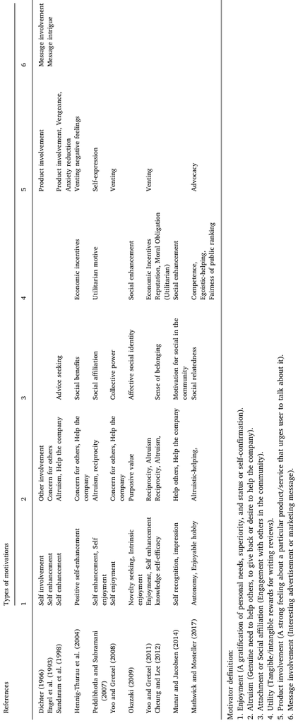

NOTE: complex table shown as an image of the PDF; the text below is a rough machine extraction and may be mis-aligned.

**extracted text (unreliable layout)**

*K. Nam, et al. Decision Support Systems 129 (2020) 113168*

3

Page 4

will go beyond prior work by examining the differing motivations for creating positive eWOM or negative eWOM.

Second, the six motives listed in Table 1 represent an inclusive list, one that contains inconsistent results. The first three motives – enjoyment, altruism, and attachment – are found to be consistently significant in affecting writers' behavior. Each are included in the present study. In the case of the fourth motive, utilitarian motivation, results are mixed. This variable is included in the present study because it is frequently reported that people intentionally write eWOM for monetary purposes [39,40]. Indeed, of the motivations that have been identified, the potential to enhance one's own self-worth, concern for others, the desire for social interaction, and economic incentives are the most influential [7]. And the last two motives – product involvement and message involvement – are the least investigated and results across previous studies are not consistent. Given the inconsistent results and only sporadic interest in the final two items in the table – product involvement and message involvement – we have excluded the last two motives without further consideration.

Third, extant eWOM research has not fully considered the influence of prior eWOM. The Expectation Confirmation Model (ECM) has been often employed as a key theoretical support to explain continued usage of information system [43,56]. Assuming that writing eWOM resembles continued information system usage, the motives of writing eWOM would be well explained with more theoretical robustness by employing the concept of expectation and its confirmation. If expectations are created by prior eWOM, then confirmation of those expectations and continued IS usage in the form of subsequent eWOM can be explained by the ECM. It may be the case that motivation for writing eWOM goes beyond the motivations listed in Table 1.

#### **3. Theoretical development**

*3.1. Theoretical background*

Given our interest in why consumers write eWOM, we focus on the post-consumption evaluation phase of consumers' decision-making [27]. Most research explains consumers' post-consumption evaluation in terms of satisfaction (or dissatisfaction) [27], where consumers' satisfaction depends on how their pre-purchase expectations compare to their post-consumption outcomes [41,42]. Consumers initially form an ex-ante expectation about a good or service prior to purchasing it, during the information search and product evaluation phases of their decision making process. Expectations are formed by prior experience, existing knowledge, mass media messages, package information, salesperson interactions, or comments from other users [27,43]. Expectation forms an anchor, a basis from which comparisons can be made [44]. After the product/service is purchased, used or consumed, consumers form a perception about the product or service. If the performance of product or service meets or exceeds the initial expectation, the consumer experiences positive expectation confirmation. If, however, product/service performance fails to exceed the consumer's initial expectation, he or she experiences disconfirmation (or negative expectation confirmation<sup>1</sup>) [45]. The consumer's level of expectation confirmation then influences the consumer's level of satisfaction. Finally, consumers form a repurchase intention based on their level of satisfaction [41,42,46]. The expectation confirmation model (ECM) is shown in Fig. 1.

This research on expectation confirmation, satisfaction, and

repurchase intention has been adapted by IS scholars, who have developed the ECM as a model of continued information system usage [47–50]. In this model, confirmation of users' expectations is positively related to their post-adoption expectations. Users continually update their post-adoption expectations as they continue to interact with an information system in light of their level of confirmed expectations. Users' updated expectations determine their level of satisfaction and likelihood to continue usage of the information system [51–53]. Postadoption expectations are positively related to satisfaction, with satisfaction then positively related to continued usage of the IS. In this model, users' post-adoption expectations are distinct from expectations that were formed before adoption and usage [47,54].

We choose to build our research model on the ECM for several reasons. First, we are interested in how a consumer's eWOM-formed level of expectation confirmation regarding a product or service influences his or her level of satisfaction with that product or service. The relationship from confirmation to satisfaction is quite clearly addressed in the ECM and related research. Second, we are interested in whether consumers contribute eWOM after experiencing a product or service. Expectations about products and services are formed in part by the eWOM that appears on review websites. Online review forums are a type of IS. When consumers read eWOM, then contribute eWOM after experiencing a product/service, their eWOM contribution behavior is a type of continued IS usage. Given that the ECM explains factors that influence continued usage of an IS, we argue that it can be utilized in the specific research context of online review websites. Confirmation with respect to expectation could be one of the important motivations for writing eWOM, a motivation that previous studies have disregarded.

Based on the ECM, we specify two types of expectation confirmation to explain eWOM writing behavior. The first type is *offline expectation confirmation*, a type that is formed based on consumers' levels of expectation confirmation with regard to a product or service experience. When consumers write eWOM on a review site, they do so on the basis of their real-world experience and expectation. They also experience another type of confirmation: *online expectation confirmation*. As we explained previously, consumers make purchase decisions based, in part, on review-based eWOM. After their purchase, it is rational for them to consider whether their time reading reviews was well-spent and valuable (or ill-spent and useless). Was the eWOM accurate and helpful? That is, previous online eWOM content is another source of expectation confirmation, which leads consumers to write positive or negative eWOM. Utilizing the ECM with two types of expectation confirmation, it is now possible to examine eWOM writing behavior more closely, where we can examine consumers' levels of expectation confirmation about eWOM and how those levels provide a basis for them to evaluate their expectations about the previously-written eWOM.

*3.2. Research model and hypotheses*

The research model for the paper appears in Fig. 2 [note that Fig. 2a shows determinants of writing positive eWOM and Fig. 2b shows determinants of writing negative eWOM]. In Fig. 2a, consumers' levels of offline expectation confirmation, that is, their levels of expectation confirmation about a real-world product or service (such as a hotel stay) determine their level of satisfaction with regard to the product or service (H1a). Then, consumers' levels of online expectation confirmation, that is, their expectations about eWOM accuracy also determine their level of satisfaction with the product or service (H2a). The distinction that we make between offline expectation confirmation related to the product/service experience and online confirmation expectation related to the eWOM is a key distinguishing feature of this research model, and part of our contribution. Next, each of these variables, offline expectation confirmation, online expectation confirmation, and satisfaction determine the likelihood of writing positive eWOM (H3a, H4a, and H5a, respectively).

1 In this paper, we use the term “disconfirmation” to identify a situation where performance fails to exceed the consumer's expectation. Similarly, we use, “confirmation” to refer to a situation when performance meets or exceeds the consumer's expectation. We prefer this usage to the double-negative term “negative disconfirmation” and its counterpart “positive disconfirmation” that have been used elsewhere.

*K. Nam, et al. Decision Support Systems 129 (2020) 113168*

4

Page 5

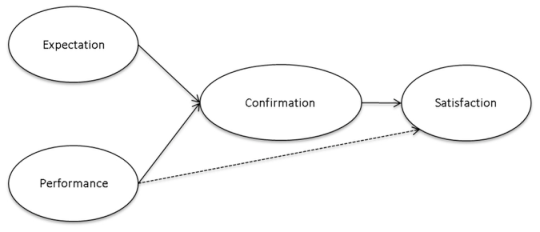

NOTE: figure/graphic rendered as an image from the PDF; its content is not machine-readable text. Caption (if any) follows as the next block.

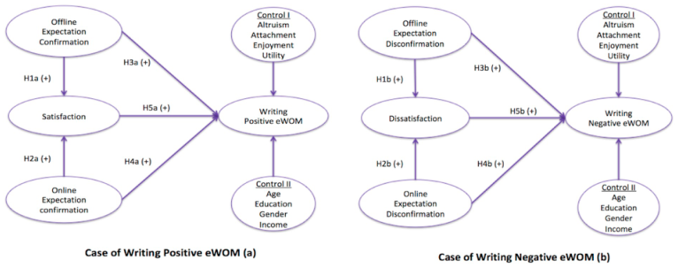

NOTE: figure/graphic rendered as an image from the PDF; its content is not machine-readable text. Caption (if any) follows as the next block.

Fig. 2b is similar, showing the determinants of writing negative eWOM. In this case, offline expectation *dis*confirmation influences *dis*satisfaction (H1b) and online expectation *dis*confirmation influences *dis*satisfaction (H2b). In turn, offline expectation *dis*confirmation, online expectation *dis*confirmation, and *dis*satisfaction determine the likelihood of writing negative eWOM (H3b, H4b, and H5b, respectively). We now fully develop the hypotheses depicted in the model and explain the directionality of each relationship.

*3.2.1. Offline expectation confirmation and satisfaction* Initially, a consumer forms an expectation about a product or service, a baseline against which he or she will make a post-consumption evaluation [41,42,45,55]. After experiencing the product/service, the consumer makes an evaluation, forming a level of satisfaction [41,45,47]. When a consumer realizes the expected benefits and product/service performance meets or exceeds expectations, this is known as positive confirmation and the consumer's satisfaction increases. Conversely, when performance lags expectations, the consumer experiences negative confirmation and satisfaction decreases [47,48,50,54–57]. Thus, confirmation and satisfaction are positively associated, while disconfirmation and dissatisfaction are similarly positively associated. To confirm this relationship, which is well-established in prior studies, we hypothesize

**Hypothesis 1a.** Offline expectation confirmation will be positively associated with satisfaction regarding a product/service that has been experienced by the consumer.

**Hypothesis 1b.** Offline expectation disconfirmation will be positively associated with dissatisfaction regarding a product/service that has been experienced by the consumer.

*3.2.2. Online expectation confirmation and satisfaction* While the initial confirmation construct, offline expectation confirmation, captures the consumer's degree of expectation confirmation regarding the real-world product or service, the additional confirmation construct of online expectation confirmation captures the expectation confirmation regarding the accuracy of prior eWOM. When using online resources such as eWOM for search and evaluation, a consumer would rationally evaluate the usefulness of their online resources. After purchase, he or she would ask, “Was my time spent reading reviews wellspent?” and “Were the reviews accurate?” and “Did my experience with the product or service align with what previous consumers said in their reviews?”

Expectations arise from a variety of sources, including personal messages and comments from other review website users [58]. eWOM is one form of such communication. Online reviews form one of the trusted sources of information for many users [17]. We observe that a consumer's post-consumption evaluation rationally includes evaluation of the product/service bundle as well as the information on which the purchase was based. A satisfied consumer may attribute his or her satisfaction both to the quality of the good or service as well as to the accuracy of information available before purchase. Similarly, a dissatisfied consumer may attribute dissatisfaction to the product/service as well as to information about the product or service. More specifically, consumers will experience a high level of satisfaction when they rationally evaluate eWOM as valuable after an eWOM-driven purchase decision and consumption experience. Conversely, a high level of dissatisfaction after an eWOM-based decision would lead the consumer to conclude that eWOM is not as valuable nor reliable as he or she had initially thought. Formally,

**Hypothesis 2a.** Online expectation confirmation will be positively

**Fig. 1.** Expectation confirmation theory (Oliver [36]).

**Fig. 2.** Research model.

*K. Nam, et al. Decision Support Systems 129 (2020) 113168*

5

Page 6

associated with satisfaction regarding an eWOM-influenced product/ service experience.

**Hypothesis 2b.** Online expectation disconfirmation will be positively associated with dissatisfaction regarding an eWOM-influenced product/ service experience.

*3.2.3. Offline and online expectation confirmation, satisfaction, and writing eWOMs*

We now examine the link between consumers' level of expectation confirmation and the likelihood of writing eWOM. The writing of eWOM is the dependent variable in this study. The phenomenon we seek to explain is why consumers write eWOM, and more specifically, why consumers choose to write either positive or negative eWOM.

After a consumer experiences a real-world, offline product or service and moves to the post-evaluation stage of the decision process, two possible situations can exist: first, the consumer may experience confirmation because expectations were met or exceeded, or second, the consumer may experience disconfirmation because expectations were not met [47,48,50,54–57]. Positive eWOM is the potential outcome of confirmation while negative eWOM is the potential outcome of disconfirmation. Indeed, marketing literature has consistently indicated that when firms fail to meet customer expectations, this leads to complaints [33], anger, regret, switching intention, and negative WOM [36,38].

We emphasize that we are not arguing that expectation confirmation should generally lead to an increase in the *amount* of eWOM generated, but that the level of expectation confirmation should lead to a specific *type* of eWOM generated. Restated, expectation confirmation should lead only to an increase in positive eWOM while expectation disconfirmation should lead only to an increase in negative eWOM. We are unaware of a rationale for positive expectation confirmation increasing negative eWOM, nor of one where negative expectation confirmation leads to positive eWOM. Our prediction is shown in Table 2.

Stated formally,

**Hypothesis 3a.** Expectation confirmation resulting from an offline experience will be positively associated with writing positive eWOM (Table 2).

**Hypothesis 3b.** Expectation disconfirmation resulting from an offline experience will be positively associated with writing negative eWOM .

With online expectation confirmation, consumers who are satisfied with the eWOM contribute positive eWOM because they expect other consumers to find the eWOM as helpful as they did. And dissatisfied consumers, that is, those who found the eWOM inaccurate, incorrect, unhelpful or not useful, will likely contribute negative eWOM out of a desire to “correct” the inaccurate eWOM that they read during their search and evaluation.

**Hypothesis 4a.** Confirmation of expectations established using online eWOM will be positively associated with writing positive eWOM.

**Hypothesis 4b.** Disconfirmation of expectations established using online eWOM will be positively associated with writing negative eWOM.

In the ECM, satisfaction increases the likelihood of continued IS usage [47–50]. Applied to the context of eWOM, it is possible to interpret eWOM contribution behavior as a type of continued information system usage. Satisfaction with a good or service would then increase the likelihood of continued usage of an IS that was initially used in consumer search and evaluation. Indeed, higher levels of satisfaction increase the likelihood of consumers submitting positive eWOM [29]. Conversely, low levels of satisfaction increase the likelihood of negative WOM [33,36,38]. We therefore hypothesize:

**Hypothesis 5a.** Satisfaction will be positively associated with writing positive eWOM.

**Hypothesis 5b.** Dissatisfaction will be positively associated with writing negative eWOM.

#### **4. Method**

*4.1. Data collection*

This study chose the TripAdvisor website for the collection of data and solicited its users to participate in our study for several reasons. First, the increasing popularity of online communities and social networking sites means that it is becoming easier to find respondents who meet the criteria for our research. The possibility of finding qualified respondents makes alternate approaches such as student sampling unnecessary. Second, and closely-related to our first point, collecting data from real-world online users increases the reliability and validity of our research results. Third, after a thorough review of several sites, we chose TripAdvisor since it is known as one of the most highly visited tourism websites with > 530 million reviews and close to 400 million unique visitors per month, providing a large pool from which to draw qualified research subjects.

After the development of a preliminary questionnaire, we gathered comments from seven individuals: two Management Information Systems and two marketing scholars, and three prospective participants. After revisions were made, we conducted a pilot test with 70 undergraduate and MBA students to make sure that the questions were unambiguous and that there were no measurement problems. Based on the result of the pilot test data analysis, several questions were refined to further improve readability and clarity.

We selected Qualtrics to assist us with data collection because they are able to contact TripAdvisor members based on their large database of potential subjects. Before formal data collection was done, we also conducted a trial collection of 30 responses to assess the data collection methods of the agency. In order to collect data while minimizing the risk of sample bias, a website was built and the survey was tested for several trials with randomly selected respondents.

Given our research objectives, we chose to survey individuals with the following three characteristics: (1) the respondent should be a member of the TripAdvisor community, (2) within the past six months the respondent had to stay in one of hotels listed on TripAdvisor and (3) the respondent had to read TripAdvisor reviews about the hotel in advance of their stay. If prospective subjects satisfied all three criteria, they were administered one of two questionnaire forms. Survey form 1 was designed to collect data from TripAdvisor members who *did* write a review after staying at a hotel; survey form 2 was designed to collect data from TripAdvisor members who *did not* write a review after their hotel stay. The two forms were developed to address our research objective of identifying the reasons why people do or do not contribute

**Table 2** Anticipated eWOM writing behavior.

[output not shown]

NOTE: table converted from PDF layout to HTML text; cell boundaries are reconstructed. See PDF if exact alignment matters.

*K. Nam, et al. Decision Support Systems 129 (2020) 113168*

6

Page 7

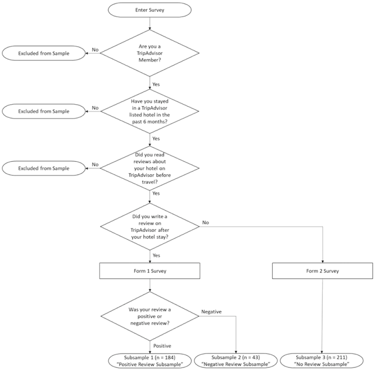

NOTE: figure/graphic rendered as an image from the PDF; its content is not machine-readable text. Caption (if any) follows as the next block.

**Fig. 3.** Survey participant screening process and subsamples.

**Table 3** Demographic characteristics of respondents (*n* = 438).

[output not shown]

NOTE: table converted from PDF layout to HTML text; cell boundaries are reconstructed. See PDF if exact alignment matters.

*K. Nam, et al. Decision Support Systems 129 (2020) 113168*

7

Page 8

eWOM to online review websites. For both survey form 1 and form 2, respondents were requested to fill out the name of the city and of the specific hotel where they stayed in order to refresh their memories as well as to increase the credibility of their responses. The participant screening process and subsamples are illustrated in the flow chart shown in Fig. 3. Ultimately, the survey administration process yielded a subsample of respondents who contributed a positive review to TripAdvisor, a subsample who contributed a negative review to TripAdvisor, and a subsample that contributed no reviews. Considering the benefits of collecting data directly from real online users, the strict screening questions to avoid sampling bias, and the recent trend of using data through online surveys, the data collection method of our study possesses sufficient reliability and un-biasedness for our research purpose.

*4.2. Development of instrument and measurement items*

In the survey, we used constructs of multiple items based on a seven-point Likert scale. Any measures that were adapted from previous studies were carefully revised and validated. (See Table 4). ECM-related variables such as offline expectation confirmation and satisfaction are directly adopted from previous studies [47,54,59,60]. Online expectation confirmation was modified based on offline expectation confirmation.

Additionally, we include two types of control variables in our model based on the precedent of prior research. Specifically, significant

relationships have been found for attachment [29,61,62], enjoyment [29,61], utility [7,29], and altruism [7,29,61]. These compose the first set of control variables. Demographic control variables (age, education, gender, and income) are included as a second set of controls.

Tests for common method bias were performed before conducting the test of the measurement model [63]. Self-reported data from the same person at one time could yield correlations that subsequently generate unintended bias about the respondent. In order to check out the risk of common method variance, we conducted two additional statistical tests: Harman's one-factor test [63] and the marker variable test [64]. We found that results of these two tests indicate that there is no clear risk of common method bias with nor any explicit evidence.

#### **5. Results and analysis**

The Partial Least Square (PLS) method was used to perform a simultaneous evaluation of the measurement model as well as the structural model. The PLS structural equation modeling (PLS-SEM) method is more suitable for theory building as well as theory testing. Given that PLS-SEM is more prediction-oriented, PLS is considered to be appropriate because this is one of the first studies to investigate the determinants that affect the writing of positive and negative eWOM.

One limitation of PLS, however, is when an endogenous variable is binary or nominal [65,66]. In such a situation, the PLS algorithm is inappropriate because ordinary least squares (OLS) assumptions are violated. For this reason, we use the PLS method as well as logistic regression together in the analysis of the structural model.

*5.1. Measurement assessment*

Cronbach's alpha (*α*) and composite reliability (CR) were used to assess the internal consistency of each construct. When scores of both tests exceed 0.7, it is accepted that constructs satisfy the internal consistency requirements [63,64]. All constructs in Table 5 show that all Cronbach's *α* values are higher than 0.7 and CRs range from 0.92 to 0.95. For convergent validity, the average variance extracted (AVE) and factor loading scores of each construct should be higher than 0.5 and 0.7, respectively [64]. Table 5 shows that AVE scores ranging from 0.74

**Table 4** Measurement items.

[output not shown]

NOTE: table converted from PDF layout to HTML text; cell boundaries are reconstructed. See PDF if exact alignment matters.

*K. Nam, et al. Decision Support Systems 129 (2020) 113168*

8

Page 9

to 0.95 and factor loadings ranging from 0.784 to 0.957 satisfy the recommended criteria.

Discriminant validity is confirmed when the correlation between pairs of construct is below 0.9, the square root of the AVE is greater than its correlation estimates, and the cross-loadings of factor score are higher in the corresponding construct than loadings in other constructs. Tables 5 and 6 confirm these three criteria of discriminant validity.

*5.2. Structural model assessment*

We used SmartPLS and logistic regression to estimate the structural

**Table 5** Cross loadings.

[output not shown]

NOTE: table converted from PDF layout to HTML text; cell boundaries are reconstructed. See PDF if exact alignment matters.

Note: OFX: offline expectation confirmation, ONX: online expectation confirmation, SAT: satisfaction, ALT: altruism, ATT: attachment, ENJ: enjoyment, UTI: utility. Loadings (in bold) and cross-loadings for the measurement model.

**Table 6** Internal consistency and validity.

[output not shown]

NOTE: table converted from PDF layout to HTML text; cell boundaries are reconstructed. See PDF if exact alignment matters.

Note: Bold face items on the diagonal are the square root of AVE. OFX: Offline Expectation Confirmation, ONX: Online Expectation Confirmation, SAT: Satisfaction with Hotel, ALT: Altruism, ATT: Attachment, ENJ: Enjoyment, UTI: Utility, EDU: Education, GDR: Gender, INC: Income, WOM: eWOM.

⁎⁎ *p* < 0.01. ⁎ *p* < 0.05.

*K. Nam, et al. Decision Support Systems 129 (2020) 113168*

9

Page 10

Logistic regression was used with a binary dependent variable for writing eWOM to test H3a, H3b, H4a, H4b, H5a and H5b. For positive eWOM, none of these hypotheses are supported. For negative eWOM, H4b (*β* = 1.730, *p* < 0.01) and H5b (*β* = 1.816, *p* < 0.05) are supported as hypothesized. Therefore, we find that the determinants of

writing negative eWOM are different from those of positive eWOM. That is, people write negative eWOM when they are dissatisfied and when their online expectations are disconfirmed (that is, when their experience contrasts with what was stated in previous eWOM). Neither expectation confirmation regarding the product/service, nor expectation confirmation regarding previous eWOM, nor satisfaction affect the behavior of writing positive reviews.

In logistic regression, the Cox & Snell R<sup>2</sup> and Nagelkerke R<sup>2</sup> are interpreted like an R<sup>2</sup> in multiple regression [73]. In this study, the Cox & Snell and Nagelkerke R<sup>2</sup> values are 40.1% and 53.5%, respectively, in the positive eWOM model; and are 51.2% and 85.8% in the negative eWOM model, indicating that the model has greater explanatory power for negative eWOM. Both models nevertheless explain a substantial amount of variance in writing eWOM.

**Table 7** Results of hypotheses tests.

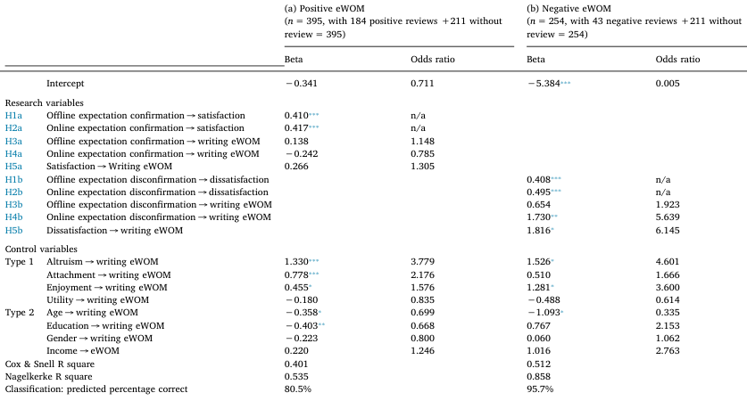

NOTE: complex table shown as an image of the PDF; the text below is a rough machine extraction and may be mis-aligned.

**extracted text (unreliable layout)**

H1a, H2a, H1b and H2b are tested using Smart PLS while other hypotheses are tested using a logistic regression model.

⁎ *p* < 0.05. ⁎⁎ *p* < 0.01. ⁎⁎⁎ *p* < 0.001.

*K. Nam, et al. Decision Support Systems 129 (2020) 113168*

10

Page 11

#### **6. Discussion**

Our main objectives in this study have been to examine why consumers contribute eWOM to online review websites, and also whether motivations for contribution differ for those who contribute positive eWOM and those who contribute negative eWOM. Our results enable us to now comment on these issues as we discuss the theoretical, methodological, and practical implications of this study.

*6.1. Theoretical implications*

Our study offers multiple contributions to theory. First, we shed light on the steps in the post-consumption evaluation portion of the consumer decision making process. Our results identify the distinct roles of expectation confirmation regarding the offline product or service, expectation confirmation regarding the online eWOM, and satisfaction. While the roles of expectation confirmation and satisfaction have long been known [41,45,55], multiple types of expectation confirmation have not been heretofore described.

Significant results for H1a, H1b, H2a, H2b, as well as H4b indicate that when eWOM is among the stimuli that consumers attend to during the pre-purchase information search and alternative evaluation stages of the decision process, two types of expectation confirmation will form during the post-consumption evaluation stage. The first is with regard to the offline product or service and the second is with regard to the online eWOM. Restated and contextualized for our study, after consumption, consumers will ask both, “Were my expectations for the hotel met?” and “In light of my experience at the hotel, were the reviews that I read beforehand accurate and helpful?” These two distinct types of expectation confirmation represent an extension of the Expectation Confirmation Model (ECM) and should influence both IS researchers studying the influence of eWOM on purchase, continuing usage, and repurchase, as well as Marketing researchers studying consumers' information search, pre-purchase alternative evaluation, and post-consumption evaluation in the Internet era.

Second, by providing empirical evidence that the motivations for writing positive and negative eWOM differ, we further contribute to explanations of post-consumption evaluation. While prior studies have provided evidence for the influence of positive and negative eWOM on consumers during the information search and pre-purchase evaluation of alternatives [74,75] – that is, the influence of eWOM on *readers* of eWOM – prior eWOM research has not thoroughly investigated the influence of eWOM on *writers* of eWOM. This study thus improves researchers' understanding of eWOM by showing that the determinants for writing positive eWOM are different from those for writing negative eWOM.

Specifically, we observe in this study that consumers write positive eWOM when they have a genuine desire to help others with their decisions (altruism), when they have a strong sense of belonging to a particular online community (attachment), and when they find writing reviews to be fun and interesting (enjoyment). Expectation confirmation and satisfaction are less influential. In our findings, members of the online community write about their positive experience after their trip

regardless of their experience with the product/service, and regardless of the accuracy and usefulness of previous eWOM. Additionally, younger consumers are more likely to write positive eWOM. This behavior may be related to the fact that younger people are known to share their happy moments with family and friends on social networking sites [76,77]. Thus, certain personal characteristics, intrinsic motivations, and hedonic drives motivate consumers to write positive eWOM; the product/service experience is much less influential.

In contrast, writers of negative eWOM write reviews primarily because they are not satisfied with the product or service (H5b) and because the perceived inaccurate content of previous eWOM (H4b). This is distinct from the observed factors that influence consumers to write positive eWOM. While altruism, enjoyment, and age factors show up as factors that stimulate the writing of negative eWOM just as they do for positive eWOM, attachment to the community is not a factor. Thus, even consumers without a strong relationship to the online community will get online to make their negative feelings known. These findings regarding the different influences on the writing of positive versus negative eWOM should shape the work of IS researchers who study eWOM writing behavior.

*6.2. Methodological implications*

One of the strengths of our study is that our results are obtained based on the analysis of post-behavior data, not on intention-oriented variables such as intention to write or continued-usage intention. The growing availability of online data, the swelling number of eWOM contributors, and the increasing number of online communities makes real-world data more widely available than in the past. Results obtained from such data offer the advantages of increased reliability and validity when compared to results obtained with intention-oriented responses in a hypothetical situation or in a controlled experimental environment. We encourage the use of real-world, post-behavior data in future studies.

*6.3. Practical implications*

Online review websites that publish eWOM are keenly interested in attracting and retaining users and in stimulating users' eWOM contributions. This study indicates that consumers contribute eWOM (both positive and negative eWOM) because of altruism and personal enjoyment. Review websites that can develop marketing and strategies to appeal to altruistic motivations will stimulate the contribution of eWOM content. Additionally, appealing to users' sense of enjoyment, perhaps through gamification, is another approach that could stimulate contributions.

Attachment to the website and its online community is identified here as a factor that stimulates positive eWOM contributions. Thus, review websites that can cultivate and reward a dedicated pool of users, perhaps through loyalty programs, will also stimulate contributions. Finally, younger users have been identified in our results as being more inclined to write eWOM. Younger people are the most consistent users of social networking sites, including online review websites [76,77]. Thus, review sites can take advantage of this insight by targeting this demographic that contributes more actively than do older users.

Additional implications exist for online review websites and hotels that use decision support systems, customer relationship management systems, or other new artificial intelligence-based customer-oriented

*K. Nam, et al. Decision Support Systems 129 (2020) 113168*

11

Page 12

applications. Some online review websites allow anyone to post a review but some sites only allow a user that actually booked a hotel through the website in the past six months to post a review. Therefore, it is possible for the hotels to identify guests by their reviewer IDs, or details of their review - they might encourage these customers to write favorable review for them. A similar step would be for hotels to solicit reviews from guests (reviews that mention factors such as cleanliness, sleep quality, location, or other characteristics) in a computer-generated, ghost-written review for the guest to post to online review websites such as TripAdvisor. Since reviews are often based on ratings and deliberate use of sentiment, it is difficult to detect dishonest posts [78]. In these ways, hotels could begin to curate the reviews that are posted on review websites for their benefits.

*6.4. Limitations and directions for future research*

As with all studies, our research has limitations. First, this study was conducted using a single website, TripAdvisor, which focuses largely on hotel reviews. The hotel industry provides a highly experience-based product/service bundle. Future research could replicate this study with other types of experience-based product/service bundles such as those concerned with restaurants, events, attractions, and activities. Replications could also be attempted with less-experience-based product/service bundles such as reviews for movies, TV programs, or music; for electronic devices such as gaming systems or smartphones; or for other products and services as well. Testing the conceptual framework of this research in other types of online communities can enable the development of a more robust and generalizable model of eWOM contribution behaviors.

Third, related to the sample characteristic of booking and reviewing hotel, our questionnaires were collected from customers who experienced (dis)confirmations with respect to a certain level of positive offline and online expectations about the hotel. We assume that this is a typical situation when consumers write reviews. If they had expected poor service in advance, they would have not stayed at the hotel. However, extreme cases are possible. For example, there might be a situation where both a prior offline and online expectations are extremely low but the consumer books anyway, and the actual experience is extremely positive. This case rarely happens in reality and requires a different research design.

Fourth and finally, future research will provide an opportunity to examine interaction effects. For instance, expectation confirmation and altruism could interact to influence the writing of eWOM. Perhaps satisfied individuals who simultaneously have a strong desire to help others, by enabling them to find the satisfying experience they themselves have had, would be more likely to author positive eWOM. While such a relationship was not borne out in our data, studies in other contexts may be able to identify such a relationship.

#### **7. Conclusion**

Prior research studies have investigated the determinants of writing eWOM as a single type of behavior. However, consumers' motivations for writing positive eWOM differ from consumers' motivations for writing negative eWOM. This paper therefore developed a model to explains why people choose (or choose not) to write eWOM, and for those who do choose to write, why they choose to write positive or negative eWOM. The use of control variables from previous studies further signifies the distinctions between the writing of positive or negative eWOM.

Moreover, prior studies of eWOM neglected to examine the influence of online factors such as previous reviews even though previous online reviews clearly influence whether eWOM writers author positive or negative eWOM. In order to overcome these shortcomings, we modified the ECM and included two distinct types of expectation confirmation: offline expectation confirmation and online expectation confirmation.

Our dataset from real-world eWOM readers and writers largely confirms our research model and identifies key differences in the motivations for writing positive and negative eWOM. Implications exist for the study of eWOM, the consumer decision-making process, and for the management of online review websites. We hope that these findings and their implications stimulate others to further investigate the ways in which consumers evaluate their experiences and, in turn, influence other consumers.

#### **Acknowledgement**

This research is funded by grant FRG19-S-B90 from the American University of Sharjah.

#### **References**

[1] J. Arndt, Role of product-related conversations in the diffusion of a new product,

Journal of Marketing Research 4 (3) (1967) 291–295. [2] G.S. Day, Attitude change, media and word of mouth, Journal of Advertising

Research 11 (6) (1971) 31–40. [3] E. Dichter, How word-of-mouth advertising works, Harvard Business Review 44 (6)

(1966) 147–160. [4] R.A. King, P. Racherla, V.D. Bush, What we know and don’t know about online

word-of-mouth: a review and synthesis of the literature, Journal of Interactive Marketing 28 (3) (2014) 167–183. [5] N. Chung, H. Han, C. Koo, Adoption of travel information in user-generated content

on social media: the moderating effect of social presence, Behaviour & Information Technology 34 (9) (2015) 902–919. [6] C.W. Yoo, G.L. Sanders, J. Moon, Exploring the effect of e-WOM participation on e-

loyalty in e-commerce, Decision Support Systems 55 (3) (2013) 669–678. [7] T. Hennig-Thurau, K.P. Gwinner, G. Walsh, D.D. Gremler, Electronic word-of-mouth

via consumer-opinion platforms: what motivates consumers to articulate themselves on the internet? Journal of Interactive Marketing 18 (1) (2004) 38–52. [8] C.M. Cheung, D.R. Thadani, The impact of electronic word-of-mouth communica-

tion: a literature analysis and integrative model, Decision Support Systems 54 (1) (2012) 461–470. [9] K.H. Hung, S.Y. Li, The influence of eWOM on virtual consumer communities: social

capital, consumer learning, and behavioral outcomes, Journal of Advertising Research 47 (4) (2007) 485–495. [10] F. Karakaya, N. Ganim Barnes, Impact of online reviews of customer care experi-

ence on brand or company selection, Journal of Consumer Marketing 27 (5) (2010) 447–457. [11] J. Lee, D.-H. Park, I. Han, The effect of negative online consumer reviews on pro-

duct attitude: an information processing view, Electronic Commerce Research and Applications 7 (3) (2008) 341–352. [12] D.K. Gauri, A. Bhatnagar, H.R. Rao, Role of word of mouth in online store loyalty,

Communications of the ACM 51 (3) (2008) 89–91. [13] J.A. Cazier, B.B. Shao, R.D.S. Louis, Sharing information and building trust through

value congruence, Information Systems Frontiers 9 (5) (2007) 515–529. [14] J. Koh, Y.-G. Kim, B. Butler, G.-W. Bock, Encouraging participation in virtual

communities, Communications of the ACM 50 (2) (2007) 68–73. [15] J. Lee, M. Agrawal, H.R. Rao, Message diffusion through social network service: the

case of rumor and non-rumor related tweets during Boston bombing 2013, Information Systems Frontiers 17 (5) (2015) 997–1005. [16] Y. Xue, H. Liang, R. Hauser, M.T. O’Hara, An empirical study of knowledge sharing

intention within virtual teams, International Journal of Knowledge Management (IJKM) 8 (3) (2012) 47–61.

*K. Nam, et al. Decision Support Systems 129 (2020) 113168*

12

Page 13

[17] Brightlocal. Local consumer review survey. BrightLocal.com, https://www.

brightlocal.com/learn/local-consumer-review-survey/, retrieved September 12, 2017 (2016). [18] B.A. Sparks, V. Browning, The impact of online reviews on hotel booking intentions

and perception of trust, Tourism Management 32 (6) (2011) 1310–1323. [19] C. Mathwick, J. Mosteller, Online reviewer engagement: a typology based on re-

viewer motivations, Journal of Service Research 20 (2) (2017) 204–218. [20] H.-N. Chen, C.-Y. Huang, An investigation into online reviewers' behavior,

European Journal of Marketing 47 (10) (2013) 1758–1773. [21] D.L. Mothersbaugh, D.I. Hawkins, Consumer Behavior: Building Marketing

Strategy, McGraw Hill Education, New York, NY, 2015. [22] U.M. Dholakia, R.P. Bagozzi, L.K. Pearo, A social influence model of consumer

participation in network- and small-group-based virtual communities, International Journal of Research in Marketing 21 (3) (2004) 241–263. [23] R.M. Schindler, B. Bickart, Published word of mouth: Referable, consumer-gener-

ated information on the internet, in: C. Hauvgedt, K. Machleit, R. Yalch (Eds.), Online Consumer Psychology: Understanding and Influencing Consumer Behavior in the Virtual World, Lawrence Erlbaum Associates, 2005, pp. 35–61. [24] C.M. Cheung, M.K. Lee, N. Rabjohn, The impact of electronic word-of-mouth: the

adoption of online opinions in online customer communities, Internet Research 18 (3) (2008) 229–247. [25] M.Y. Cheung, C. Luo, C.L. Sia, H. Chen, Credibility of electronic word-of-mouth:

informational and normative determinants of on-line consumer recommendations, International Journal of Electronic Commerce 13 (4) (2009) 9–38. [26] M. Shu, N. Scott, Influence of social media on Chinese students’ choice of an

overseas study destination: an information adoption model perspective, Journal of Travel & Tourism Marketing 31 (2) (2014) 286–302. [27] R.D. Blackwell, P.W. Miniard, J.F. Engel, Consumer Behavior, South-Western

Thomas Learning, Mason, OH, 2006. [28] D.S. Sundaram, K. Mitra, C. Webster, Word-of-mouth communications: a motiva-

tional analysis, in: J.W. Alba, J.W. Hutchinson (Eds.), NA - Advances in Consumer Research, Association for Consumer Research, Provo, UT, 1998, pp. 527–531. [29] N.B. Peddibhotla, M.R. Subramani, Contributing to public document repositories: a

critical mass theory perspective, Organization Studies 28 (3) (2007) 327–346. [30] S. Okazaki, Social influence model and electronic word of mouth: PC versus Mobile

internet, International Journal of Advertising 28 (3) (2009) 439–472. [31] R. Bougie, R. Pieters, M. Zeelenberg, Angry customers don’t come back, they get

back: the experience and behavioral implications of anger and dissatisfaction in services, Journal of the Academy of Marketing Science 31 (4) (2003) 377–393. [32] J.G. Blodgett, D.H. Granbois, R.G. Walters, The effects of perceived justice on

complainants’ negative word-of-mouth behavior and repatronage intentions, Journal of Retailing 69 (4) (1993) 399–428. [33] M.L. Richins, Negative word-of-mouth by dissatisfied consumers: a pilot study, The

Journal of Marketing 47 (1) (1983) 68–78. [34] J.L. Ferguson, W.J. Johnston, Customer response to dissatisfaction: a synthesis of

literature and conceptual framework, Industrial Marketing Management 40 (1) (2011) 118–127. [35] M. Zeelenberg, W.W. van Dijk, A.S.R. Manstead, J. vanr de Pligt, On bad decisions

and disconfirmed expectancies: the psychology of regret and disappointment, Cognition and Emotion 14 (4) (2000) 521–541. [36] I. Sánchez-García, R. Currás-Pérez, Effects of dissatisfaction in tourist services: the

role of anger and regret, Tourism Management 32 (6) (2011) 1397–1406. [37] I.M. Wetzer, M. Zeelenberg, R. Pieters, “Never eat in that restaurant, I did!”: ex-

ploring why people engage in negative word-of-mouth communication, Psychology & Marketing 24 (8) (2007) 661–680. [38] M. Zeelenberg, R. Pieters, Beyond valence in customer dissatisfaction: a review and

new findings on behavioral responses to regret and disappointment in failed services, Journal of Business Research 57 (4) (2004) 445–455. [39] N. Cavazza, M. Guidetti, Fake online reviews: a study on eWOM influence when

suspicions arise, Psicologia Sociale 9 (1) (2014) 71–82. [40] S.W. Litvin, R.E. Goldsmith, B. Pan, Electronic word-of-mouth in hospitality and

tourism management, Tourism Management 29 (3) (2008) 458–468. [41] R.L. Oliver, A cognitive model of the antecedents and consequences of satisfaction

decisions, Journal of Marketing Research 17 (4) (1980) 460–469. [42] R.L. Oliver, Cognitive, affective, and attribute bases of the satisfaction response,

Journal of Consumer Research 20 (3) (1993) 418–430. [43] V.A. Zeithaml, A. Parasuraman, L.L. Berry, Delivering Quality Service: Balancing

Customer Perceptions and Expectations, Simon and Schuster, 1990. [44] D. Halstead, The use of comparison standards in customer satisfaction research and

management: a review and proposed typology, Journal of Marketing Theory and Practice 7 (3) (1999) 13–26. [45] R.L. Oliver, Effect of expectation and disconfirmation on postexposure product

evaluations: an alternative interpretation, Journal of Applied Psychology 62 (4) (1977) 480. [46] E.W. Anderson, M.W. Sullivan, The antecedents and consequences of customer

satisfaction for firms, Marketing Science 12 (2) (1993) 125–143. [47] A. Bhattacherjee, Understanding information systems continuance: an expectation-

confirmation model, MIS Quarterly 25 (3) (2001) 351–370. [48] N. Chung, H. Lee, S.J. Lee, C. Koo, The influence of tourism website on Tourists’

behavior to determine destination selection: a case study of creative economy in Korea, Technological Forecasting and Social Change 96 (2015) 130–143. [49] M.A. Hossain, M. Quaddus, Expectation–confirmation theory in information sys-

tems research: A review and analysis, Information Systems Theory, Springer, 2012, pp. 441–469. [50] C.-L. Hsu, J.C.-C. Lin, What drives purchase intention for paid Mobile apps? An

expectation confirmation model with perceived value, Electronic Commerce

Research and Applications 14 (1) (2015) 46–57. [51] F.D. Davis, Perceived usefulness, perceived ease of use, and user acceptance of

information technology, MIS Quarterly 13 (3) (1989) 319–339. [52] E. Karahanna, D.W. Straub, Information technology adoption across time: a cross-

sectional comparison of pre-adoption and post-adoption beliefs, MIS Quarterly 23 (2) (1999) 183–213. [53] V. Venkatesh, Determinants of perceived ease of use: integrating control, intrinsic

motivation, and emotion into the technology acceptance model, Information Systems Research 11 (4) (2000) 342–365. [54] J.Y. Thong, S.-J. Hong, K.Y. Tam, The effects of post-adoption beliefs on the ex-

pectation-confirmation model for information technology continuance, International Journal of Human-Computer Studies 64 (9) (2006) 799–810. [55] R.L. Oliver, W.S. DeSarbo, Response determinants in satisfaction judgments,

Journal of Consumer Research 14 (4) (1988) 495–507. [56] S. Erevelles, C. Leavitt, A comparison of current models of consumer satisfaction/

dissatisfaction, Journal of Consumer Satisfaction, Dissatisfaction and Complaining Behavior 5 (10) (1992) 104–114. [57] R.A. Spreng, S.B. MacKenzie, R.W. Olshavsky, A reexamination of the determinants

of consumer satisfaction, The Journal of Marketing 60 (3) (1996) 15–32. [58] G. Premkumar, A. Bhattacherjee, Explaining information technology usage: a test of

competing models, Omega 36 (1) (2008) 64–75. [59] C.S. Lin, S. Wu, R.J. Tsai, Integrating perceived playfulness into expectation-con-

firmation model for web portal context, Information & Management 42 (5) (2005) 683–693. [60] V. Venkatesh, S. Goyal, Expectation disconfirmation and technology adoption:

polynomial modeling and response surface analysis, MIS Quarterly 34 (2) (2010) 281–303. [61] C.M. Cheung, M.K. Lee, What drives consumers to spread electronic word of mouth

in online consumer-opinion platforms, Decision Support Systems 53 (1) (2012) 218–225. [62] C.-C. Huang, T.-C. Lin, K.-J. Lin, Factors affecting pass-along email intentions

(PAEIs): integrating the social capital and social cognition theories, Electronic Commerce Research and Applications 8 (3) (2009) 160–169. [63] P.M. Podsakoff, S.B. MacKenzie, J.Y. Lee, N.P. Podsakoff, Common method biases in

behavioral research: a critical review of the literature and recommended remedies, Journal of Applied Psychology 88 (5) (2003) 879. [64] M.K. Lindell, D.J. Whitney, Accounting for common method variance in cross-sec-

tional research designs, Journal of Applied Psychology 86 (1) (2001) 114. [65] J.F. Hair, M. Sarstedt, C.M. Ringle, J.A. Mena, An assessment of the use of partial

least squares structural equation modeling in marketing research, Journal of the Academy of Marketing Science 40 (3) (2012) 414–433. [66] E. Jakobowicz, C. Derquenne, A modified PLS path modeling algorithm handling

reflective categorical variables and a new model building strategy, Computational Statistics & Data Analysis 51 (8) (2007) 3666–3678. [67] C.-Y.J. Peng, K.L. Lee, G.M. Ingersoll, An introduction to logistic regression analysis

and reporting, The Journal of Educational Research 96 (1) (2002) 3–14. [68] J. Cohen, Statistical Power Analysis for the Behavioral Sciences, 2nd ed., Lawrence

Earlbaum Associates, Hillsdale, NJ, 1988. [69] H. Liang, N. Saraf, Q. Hu, Y. Xue, Assimilation of Enterprise systems: the effect of

institutional pressures and the mediating role of top management, MIS Quarterly 31 (1) (2007) 59–87. [70] J. Cohen, Statistical Power Analysis for the Behavioral Sciences, Lawrence Erlbaum

Associates, Hillsdale, NJ, 1988. [71] J.-M. Becker, Re: dependent variable - continuous versus categoric, SmartPLS

Forum, http://forum.smartpls.com/viewtopic.php?f=5&t=15506&p=25536& hilit=binary+dependent+variable#p25542, (2016) , Accessed date: 19 September 2017. [72] N. Kock, Dichotomous variables, WarpPLS, http://warppls.blogspot.co.nz/2014/

05/dichotomous-variables.html, (2014) , Accessed date: 19 September 2017. [73] Wuensch, K.L. Binary logistic regression with SPSS. ECU Psych SPSS, http://core.

ecu.edu/psyc/wuenschk/MV/multReg/Logistic-SPSS.pdf, retrieved April 5, 2017 (2014). [74] J.A. Chevalier, D. Mayzlin, The effect of word of mouth on sales: online book re-

views, Journal of Marketing Research 43 (3) (2006) 345–354. [75] W. Zhang, S.A. Watts, Capitalizing on content: information adoption in two online

communities, Journal of the Association for Information Systems 9 (2008) 2. [76] S.-C. Chu, Y. Kim, Determinants of consumer engagement in electronic word-of-

mouth (eWOM) in social networking sites, International Journal of Advertising 30 (1) (2011) 47–75. [77] J. Kietzmann, A. Canhoto, Bittersweet! Understanding and managing electronic

word of mouth, Journal of Public Affairs 13 (2) (2013) 146–159. [78] N. Hu, I. Bose, N.S. Koh, L. Liu, Manipulation of online reviews: an analysis of

ratings, readability, and sentiments, Decision Support Systems 52 (3) (2012) 674–684. [79] S. Melián-González, J. Bulchand-Gidumal, B. González López-Valcárcel, Online

customer reviews of hotels: as participation increases, better evaluation is obtained, Cornell Hospitality Quarterly 54 (3) (2013) 274–283. [80] G. Zervas, D. Proserpio, J. Byers, A First Look at Online Reputation on Airbnb,

Where Every Stay is Above Average, papers.ssrn.com, 2015. [81] V. Venkatesh, J.Y. Thong, X. Xu, Consumer Acceptance and Use of Information

Technology: Extending the Unified Theory of Acceptance and Use of Technology, MIS Quarterly 36 (1) (2012) 157–178. [82] J.P. Rushton, R.D. Chrisjohn, G.C. Fekken, The Altruistic Personality and the Self-

Report Altruism Scale, Personality and Individual Differences 2 (4) (1981) 293–302. [83] N. Chung, K. Nam, C. Koo, Examining information sharing in social networking

*K. Nam, et al. Decision Support Systems 129 (2020) 113168*

13

Page 14

communities: Applying theories of social capital and attachment, Telematics and Informatics 33 (1) (2016) 77–91. [84] Y. Lee, A.N. Chen, V. Ilie, Can Online Wait be Managed? The Effect of Filler

Interfaces and Presentation Modes on Perceived Waiting Time Online, MIS Quarterly 36 (2) (2012) 365–394. [85] S.S. Kim, J.-Y. Son, Out of Dedication or Constraint? A Dual Model of Post-Adoption

Phenomena and Its Empirical Test in the Context of Online Services, MIS Quarterly 33 (1) (2009) 49–70.

**Kichan Nam** is a professor at American University of Sharjah in UAE. He received his Ph.D in Management Information Systems from the State University of New York at Buffalo and was a professor of MIS at Sogang University in South Korea. His major research topics are IT outsourcing, e-business, IT service management, service science, smart tourism, and e-government. His publications are found in major international journals such as *MIS Quarterly*, *Information Systems Research*, *Communications of the ACM*, *Journal of Management Information Systems*, *Information systems Frontiers*, and other journals.

**Jeff Baker** is an Associate Professor at the American University of Sharjah. His research focuses on IT strategy, with emphases on strategic alignment, strategies in electronic commerce, and the business value of IT. His research has appeared in the Journal of the AIS, the Journal of Strategic Information Systems, Decision Support Systems,

Communications of the AIS, and other journals.

**Norita Ahmad** is an Associate Professor of MIS at American University of Sharjah. She received her PhD in Decision Science Engineering Systems from Rensselaer Polytechnic Institute (RPI). Her research interest includes performance measurement in comparative methodologies, decision analysis, and technology adoption in business and education. She presented research internationally and published in a variety of scholarly journals such as International Journal of Information Technology & Decision Making, Journal of Intelligent Manufacturing, European Business Review, Journal of Knowledge Management and Journal of Business Ethics.

**Jahyun Goo** is an Associate Professor in the Department of Information Technology and Operations Management of College of Business at Florida Atlantic University. Besides significant pedagogical contributions to undergraduate, MBA, and Ph.D. teaching, he has renowned for an excellent researcher. He has won the researcher of the year award in 2009, 2011, and 2017 at the Florida Atlantic University. His papers have been published in MIS Quarterly, Decision Sciences, Information & Management, Decision Support Systems, Information Systems Journal, and Information Systems Frontier, among others. He has served for major journals as either an associate editor or a coordinating editor. Most recently, his research focuses on areas of IS sourcing, healthcare IT and analytics, information assurance, and IT and tourism. He received Ph.D. in MIS from the State University of New York at Buffalo.

*K. Nam, et al. Decision Support Systems 129 (2020) 113168*

14